# Psych 254 W15 PS #3

# Part 2: The Linear Model

## 2A: Basic Linear Modeling

Let’s use the `ToothGrowth` dataset, on guineapig teeth based on orange juice and vitamin C. This is super simple. (Try `?ToothGrowth`).

First plot the data, we’ll use `qplot` to understand how `len` (tooth length) depends on `dose` (amount of Vitamin C) and `supp` (delivery method).

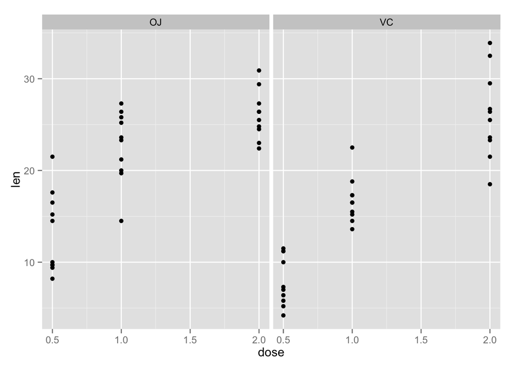

```r
library(ggplot2)
qplot(data = ToothGrowth, y = len, x = dose, facets = ~supp)
```

So now you see what’s going on.

Next, always make a histogram of the DV before making a linear model! This reveals the distribution and can be helpful in choosing your model type.

```
## stat_bin: binwidth defaulted to range/30. Use 'binwidth = x' to adjust this.
```

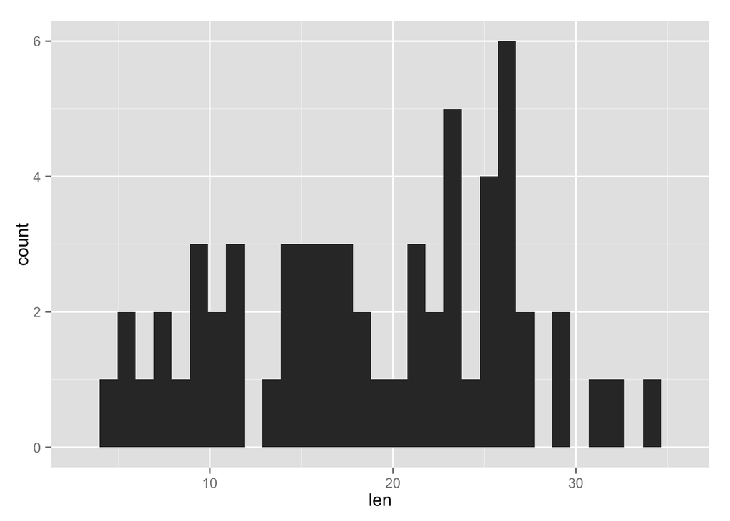

```r
qplot(data=ToothGrowth, x=len, geom="histogram")
```

Now make a linear model of tooth lengths using `lm`. Try making one with main effects and interactions and another with just main effects. Make sure to assign them to variables so that you can get them later.

```r
lm1 <- lm(len~dose+supp, data=ToothGrowth)
summary(lm1)
```

```
##
## Call:
## lm(formula = len ~ dose + supp, data = ToothGrowth)
##
## Residuals:
##    Min     1Q Median     3Q    Max
## -6.600 -3.700  0.373  2.116  8.800
##
## Coefficients:
##             Estimate Std. Error t value Pr(>|t|)
## (Intercept)    9.273      1.282    7.23  1.3e-09 ***
## dose           9.764      0.877   11.14  6.3e-16 ***
## suppVC        -3.700      1.094   -3.38   0.0013 **
## ---
## Signif. codes:  0 '***' 0.001 '**' 0.01 '*' 0.05 '.' 0.1 ' ' 1
##
## Residual standard error: 4.24 on 57 degrees of freedom
## Multiple R-squared:  0.704,  Adjusted R-squared:  0.693
## F-statistic: 67.7 on 2 and 57 DF,  p-value: 8.72e-16
```

```r
lm2 <- lm(len~dose*supp, data=ToothGrowth)
summary(lm2)
```

```
##
## Call:
## lm(formula = len ~ dose * supp, data = ToothGrowth)
##
## Residuals:
##    Min     1Q Median     3Q    Max
##  -8.23  -2.85   0.05   2.29   7.94
##
## Coefficients:
##             Estimate Std. Error t value Pr(>|t|)
## (Intercept)    11.55       1.58    7.30  1.1e-09 ***
## dose            7.81       1.20    6.53  2.0e-08 ***
## suppVC         -8.26       2.24   -3.69  0.00051 ***
## dose:suppVC     3.90       1.69    2.31  0.02463 *
## ---
## Signif. codes:  0 '***' 0.001 '**' 0.01 '*' 0.05 '.' 0.1 ' ' 1
##
## Residual standard error: 4.08 on 56 degrees of freedom
## Multiple R-squared:  0.73,   Adjusted R-squared:  0.715
## F-statistic: 50.4 on 3 and 56 DF,  p-value: 6.52e-16
```

Now try taking out the intercept, using a -1 term in the formula. what does this do?

```r
lm3 <- lm(len~dose*supp-1, data=ToothGrowth)
summary(lm3)
```

```
##
## Call:
## lm(formula = len ~ dose * supp - 1, data = ToothGrowth)
##
## Residuals:
##    Min     1Q Median     3Q    Max
##  -8.23  -2.85   0.05   2.29   7.94
##
## Coefficients:
##             Estimate Std. Error t value Pr(>|t|)
## dose            7.81       1.20    6.53  2.0e-08 ***
## suppOJ         11.55       1.58    7.30  1.1e-09 ***
## suppVC          3.30       1.58    2.08    0.042 *
## dose:suppVC     3.90       1.69    2.31    0.025 *
## ---
## Signif. codes:  0 '***' 0.001 '**' 0.01 '*' 0.05 '.' 0.1 ' ' 1
##
## Residual standard error: 4.08 on 56 degrees of freedom
## Multiple R-squared:  0.962,  Adjusted R-squared:  0.959
## F-statistic:  356 on 4 and 56 DF,  p-value: <2e-16
```

Thought question: Take a moment to interpret the coefficients of the model. Q1 - What are the units? Q2 - How does the interaction relate to the plot? Q3 - Should there be an interaction in the model? What does it mean? How important is it?

Now make predictions from the model you like the best. What should happen with doses of 0, 1.5, 2.5, and 10 under both supplements?

HINT: use the `predict` function …

HINT 2: you will have to make a dataframe to do the prediction with, so use something like `data.frame(dose=...)`.

```r
predict(lm2, newdata=data.frame(dose=0, supp="OJ")) # predicted len = 11.55
```

```
##     1
## 11.55
```

```r
predict(lm2, newdata=data.frame(dose=0, supp="VC")) # predicted len = 3.295
```

```
##     1
## 3.295
```

```r
predict(lm2, newdata=data.frame(dose=1.5, supp="OJ")) # predicted len = 23.27
```

```
##     1
## 23.27
```

```r
predict(lm2, newdata=data.frame(dose=1.5, supp="VC")) # predicted len = 20.87
```

```
##     1
## 20.87
```

```r
predict(lm2, newdata=data.frame(dose=2.5, supp="OJ")) # predicted len = 31.08
```

```
##     1
## 31.08
```

```r
predict(lm2, newdata=data.frame(dose=2.5, supp="VC")) # predicted len = 32.58
```

```
##     1
## 32.58
```

```r
predict(lm2, newdata=data.frame(dose=10, supp="OJ")) # predicted len = 89.66
```

```
##     1
## 89.66
```

```r
predict(lm2, newdata=data.frame(dose=10, supp="VC")) # predicted len = 120.45
```

```
##     1
## 120.5
```

Now plot the residuals from the original model. How do they look? HINT: `?resid`

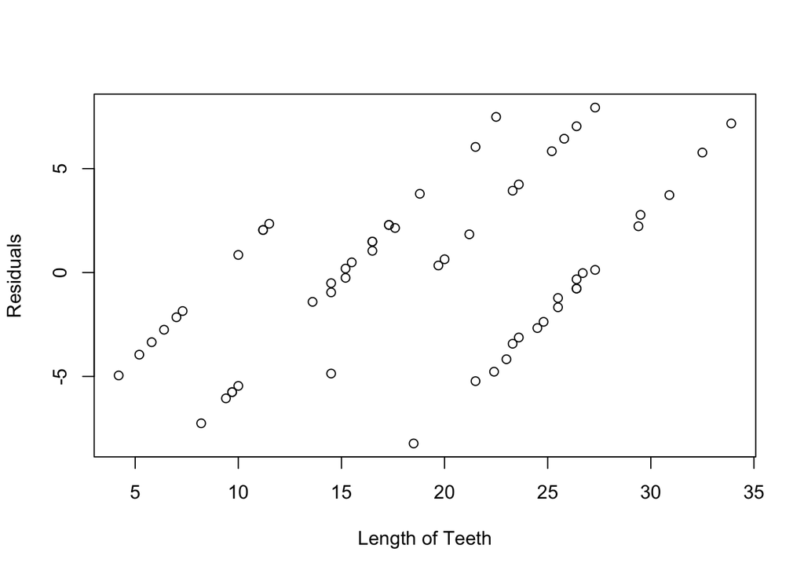

```r
lm.res <- resid(lm2)

plot(ToothGrowth$len, lm.res, ylab="Residuals", xlab="Length of Teeth")
```

BONUS: test them for normality of distribution using a quantile-quantile plot.

HINT: `?qqplot` and `?qqnorm`

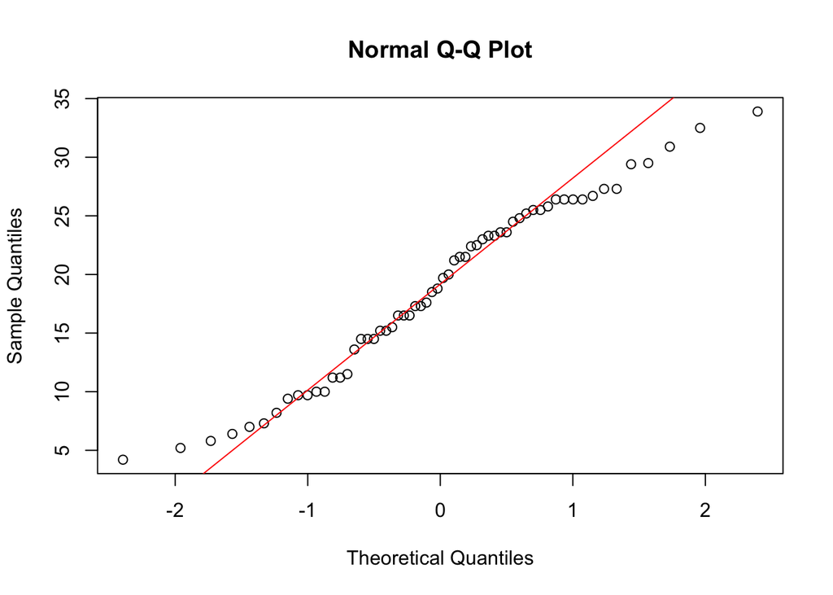

```r
qqnorm(ToothGrowth$len);qqline(ToothGrowth$len, col = 2)
```

## 2B: Exploratory Linear Modeling

What the heck is going on? Load data from Frank, Vul, Saxe (2011, Infancy), a study in which we measured infants’ looking to hands in moving scenes. There were infants from 3 months all the way to about two years, and there were two movie conditions (`Faces_Medium`, in which kids played on a white background, and `Faces_Plus`, in which the backgrounds were more complex and the people in the videos were both kids and adults). Forgive our bad naming conventions.

Try to figure out what the most reasonable linear model of the data is.

```r
d <- read.csv("../data/FVS2011-hands.csv")
head(d)
```

```
##   subid   age    condition hand.look
## 1     2 3.156 Faces_Medium   0.03188
## 2    93 5.030 Faces_Medium   0.11885
## 3    29 5.852 Faces_Medium   0.09212
## 4    76 5.852 Faces_Medium   0.12961
## 5    48 6.082 Faces_Medium   0.01379
## 6   101 6.148 Faces_Medium   0.04385
```

```
## stat_bin: binwidth defaulted to range/30. Use 'binwidth = x' to adjust this.
```

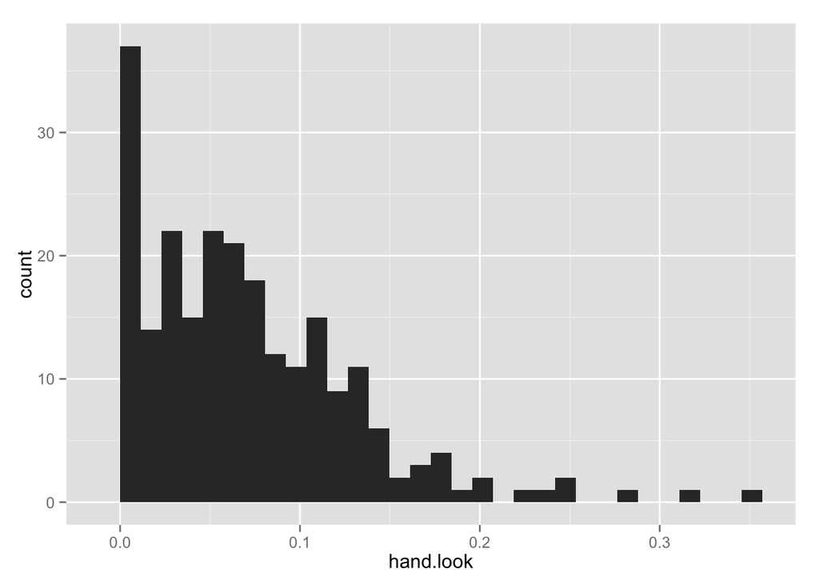

```r
qplot(data=d, x=hand.look, geom="histogram")
```

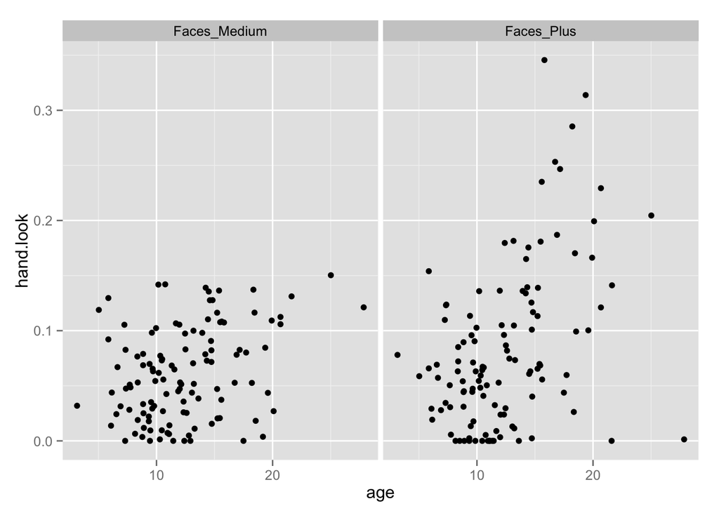

```r
qplot(data=d, y=hand.look, x=age, facets=~condition)
```

```r
d.lm <- lm(hand.look~age, data=d)
summary(d.lm)
```

```
##
## Call:
## lm(formula = hand.look ~ age, data = d)
##
## Residuals:
##      Min       1Q   Median       3Q      Max
## -0.14963 -0.04033 -0.00475  0.02764  0.25643
##
## Coefficients:
##             Estimate Std. Error t value Pr(>|t|)
## (Intercept) 0.007918   0.011115    0.71     0.48
## age         0.005138   0.000848    6.06  5.5e-09 ***
## ---
## Signif. codes:  0 '***' 0.001 '**' 0.01 '*' 0.05 '.' 0.1 ' ' 1
##
## Residual standard error: 0.0559 on 230 degrees of freedom
## Multiple R-squared:  0.138,  Adjusted R-squared:  0.134
## F-statistic: 36.7 on 1 and 230 DF,  p-value: 5.5e-09
```

Plot that model on the same plot as the data.

HINT: you can do this either using `predict` or (if you are feeling confident of your understanding of the models) using the built-in linear models in `ggplot`’s `geom_smooth`.

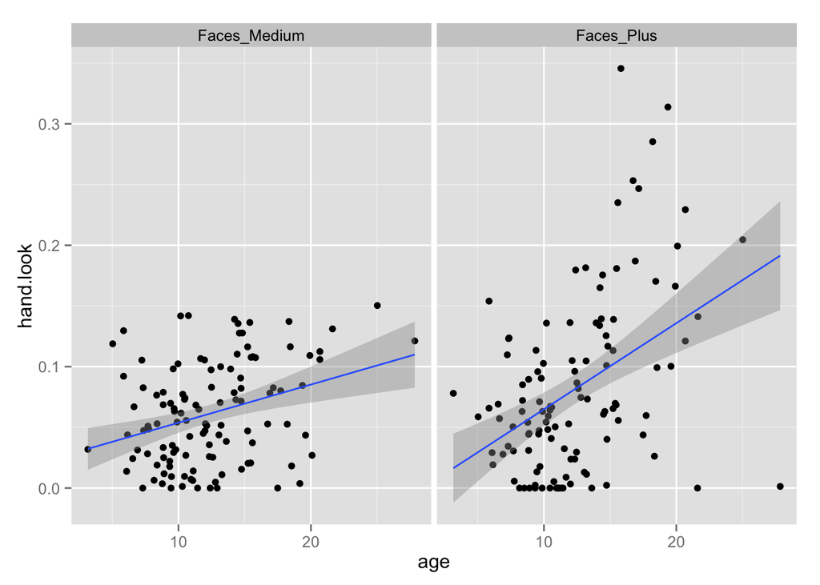

```r
qplot(data=d, y=hand.look, x=age, facets=~condition) + geom_smooth(method=lm)
```

What do you conclude from this pattern of data?